# Estimating and Evaluating the Optimal Subgroup

```r
library(polle)
library(data.table)
```

This vignette showcase how `policy_learn()` and `policy_eval()` can be combined to estimate and evaluate the optimal subgroup in the single-stage case. We refer to (Nordland and Holst 2026) for the syntax and methodological context.

# Setup

From here on we consider the single-stage case with a binary action set $\{0,1\}$. For a given threshold $\eta > 0$ we can formulate the optimal subgroup function via the conditional average treatment effect (CATE/blip) as

$$\begin{align*}
d^\eta_0(v)_ = I\{B_0(v) > \eta\},
\end{align*}$$
where $B_0$ is the CATE defined as
$$\begin{align*}
E\left[U^{(1)} - U^{(0)} \big | V = v \right].
\end{align*}$$

The average treatment effect in the optimal subgroup is now defined as
$$\begin{align*}
E\left[U^{(1)} - U^{(0)} \big | d^\eta_0(V) = 1 \right],
\end{align*}$$

which under consistency, positivity and randomization is identified as

$$\begin{align*}
E\left[Z(1,g_0,Q_0)(O) - Z(0,g_0,Q_0)(O) \big | d^\eta_0(V) = 1 \right],
\end{align*}$$

where $Z(a,g,Q)(O)$ is the doubly robust score for treatment $a$ and

$$\begin{align*}
d^\eta_0(v) &= I\{B_0(v) > \eta\}\\
B_0(v) &= E\left[Z(1,g_0,Q_0)(O) - Z(0,g_0,Q_0)(O) \big | V = v
\right]
\end{align*}$$

# Threshold policy learning

In `polle` the threshold policy $d_\eta$ can be estimated using `policy_learn()` via the `threshold` argument, and the average treatment effect in the subgroup can be estimated using `policy_eval()` setting `target = subgroup`.

Here we consider an example using simulated data:

```r
par0 <- list(a = 1, b = 0, c = 3)
sim_d <- function(n, par=par0, potential_outcomes = FALSE) {
  W <- runif(n = n, min = -1, max = 1)
  L <- runif(n = n, min = -1, max = 1)
  A <- rbinom(n = n, size = 1, prob = 0.5)
  U1 <- W + L + (par$c*W + par$a*L + par$b) # U^1
  U0 <- W + L # U^0
  U <- A * U1 + (1 - A) * U0 + rnorm(n = n)
  out <- data.table(W = W, L = L, A = A, U = U)
  if (potential_outcomes == TRUE) {
    out$U0 <- U0
    out$U1 <- U1
  }
  return(out)
}
```

Note that in this simple case $U^{(1)} - U^{(0)} = cW + aL + b$.

```r
set.seed(1)
d <- sim_d(n = 200)
pd <- policy_data(
    d,
    action = "A",
    covariates = list("W", "L"),
    utility = "U"
)
```

We set a correctly specified policy learner using `policy_learn()` with `type = "blip"` and set a threshold of $\eta = 1$:

```r
pl1 <- policy_learn(
  type = "blip",
  control = control_blip(blip_models = q_glm(~ W + L)),
  threshold = 1
)
```

When then apply the policy learner based on the correctly specified nuisance models. Furthermore, we extract the corresponding policy actions, where $d_N(Z,L) = 1$ identifies the optimal subgroup for $\eta = 1$:

```r
po1 <- pl1(
  policy_data = pd,
  g_models = g_glm(~ 1),
  q_models = q_glm(~ A * (W + L))
)
pf1 <- get_policy(po1)
pa <- pf1(pd)
```

In the following plot, the black line indicates the boundary for the true optimal subgroup. The dots represent the estimated threshold policy:

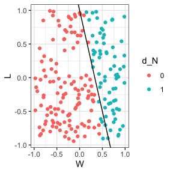

Similarly, we can also use `type = "ptl"` to fit a policy tree with a given threshold for not choosing the reference action (first action in action set in alphabetical order)

```r
get_action_set(pd)[1] # reference action
```

```
## [1] "0"
```

```r
pl1_ptl <- policy_learn(
    type = "ptl",
    control = control_ptl(policy_var = c("W", "L")),
    threshold = 1
)
po1_ptl <- pl1_ptl(
  policy_data = pd,
  g_models = g_glm(~ 1),
  q_models = q_glm(~ A * (W + L))
)
po1_ptl$ptl_objects
```

```
## $stage_1
## $stage_1$threshold_1
## policy_tree object
## Tree depth:  2
## Actions:  1: 0 2: 1
## Variable splits:
## (1) split_variable: W  split_value: -0.0948583
##   (2) split_variable: W  split_value: -0.107529
##     (4) * action: 1
##     (5) * action: 2
##   (3) split_variable: W  split_value: 0.197522
##     (6) * action: 1
##     (7) * action: 2
```

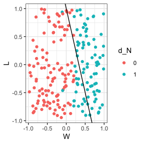

# Subgroup average treatment effect

The true subgroup average treatment effect is given by:

$$\begin{align*}
E[cW + aL + b | cW + aL + b \geq \eta ],
\end{align*}$$

which we can easily approximate:

```r
set.seed(1)
approx <- sim_d(n = 1e7, potential_outcomes = TRUE)
(sate <- with(approx, mean((U1 - U0)[(U1 - U0 >= 1)])))
```

```
## [1] 2.082982
```

```r
rm(approx)
```

The subgroup average treatment effect associated with the learned optimal threshold policy can be directly estimated using `policy_eval()` via the `target` argument:

```r
(pe <- policy_eval(
  policy_data = pd,
  policy_learn = pl1,
  target = "subgroup"
 ))
```

```
##                                 Estimate Std.Err   2.5%   97.5%   P-value
## E[U(1)-U(0)|d=1]: d=blip(eta=1)   1.9407  0.2614  1.428  2.4531 1.136e-13
## E[U(1)-U(0)|d=0]: d=blip(eta=1)  -0.8251  0.2165 -1.249 -0.4008 1.380e-04
```

We can also estimate the subgroup average treatment effect for a set of thresholds at once:

```r
pl_set <- policy_learn(
  type = "blip",
  control = control_blip(blip_models = q_glm(~ W + L)),
  threshold = c(0, 1)
)

policy_eval(
  policy_data = pd,
  g_models = g_glm(~ 1),
  q_models = q_glm(~ A * (W + L)),
  policy_learn = pl_set,
  target = "subgroup"
)
```

```
##                                 Estimate Std.Err   2.5%   97.5%   P-value
## E[U(1)-U(0)|d=1]: d=blip(eta=0)   1.6407  0.2161  1.217  2.0642 3.118e-14
## E[U(1)-U(0)|d=0]: d=blip(eta=0)  -1.4869  0.2273 -1.932 -1.0413 6.125e-11
## E[U(1)-U(0)|d=1]: d=blip(eta=1)   1.9352  0.2612  1.423  2.4472 1.268e-13
## E[U(1)-U(0)|d=0]: d=blip(eta=1)  -0.8218  0.2160 -1.245 -0.3984 1.423e-04
```

## Asymptotics

The data adaptive target parameter

$$\begin{align*}
E[U^{(1)} - U^{(0)}| d_N(V) = 1] = E[Z_0(1,g,Q)(O) - Z_0(0,g,Q)(O)|
d_N(V) = 1]
\end{align*}$$

is asymptotically normal with influence function

$$\begin{align*}
\frac{1}{P(d'(\cdot) = 1)} I\{d'(\cdot) = 1\}\left\{Z(1,g,Q)(O)
- Z(0,g,Q)(O) - E[Z(1,g,Q)(O) - Z(0,g,Q)(O) | d'(\cdot) =
1]\right\},
\end{align*}$$

where $d'$ is the limiting policy of $d_N$. The fitted influence curve can be extracted using `IC()`:

```r
IC(pe) |> head()
```

```
##   E[U(1)-U(0)|d=1]: d=blip(eta=1) E[U(1)-U(0)|d=0]: d=blip(eta=1)
## 1                        0.000000                       0.9249275
## 2                        0.000000                       2.7932280
## 3                        0.000000                       8.0530517
## 4                       -1.780405                       0.0000000
## 5                        0.000000                       2.2796112
## 6                        9.520253                       0.0000000
```

# References

Nordland, Andreas, and Klaus Kähler Holst. 2026. “Policy Learning with the polle Package.” *Journal of Statistical Software* 116 (4): 1–51. https://doi.org/10.18637/jss.v116.i04.